# Supervised Learning : Implementing Shapley Additive Explanations for Interpreting Feature Contributions in Penalized Cox Regression

### John Pauline Pineda *July 28, 2024*

- **1. Table of Contents**
  - 1.1 Data Background
  - 1.2 Data Description
  - 1.3 Data Quality Assessment
  - 1.4 Data Preprocessing
    - 1.4.1 Data Cleaning
    - 1.4.2 Missing Data Imputation
    - 1.4.3 Outlier Treatment
    - 1.4.4 Collinearity
    - 1.4.5 Shape Transformation
    - 1.4.6 Centering and Scaling
    - 1.4.7 Data Encoding
    - 1.4.8 Preprocessed Data Description
  - 1.5 Data Exploration
    - 1.5.1 Exploratory Data Analysis
    - 1.5.2 Hypothesis Testing
  - 1.6 Predictive Model Development
    - 1.6.1 Premodelling Data Description
    - 1.6.2 Cox Regression with No Penalty
    - 1.6.3 Cox Regression With Full L1 Penalty
    - 1.6.4 Cox Regression With Full L2 Penalty
    - 1.6.5 Cox Regression With Equal L1|L2 Penalty
    - 1.6.6 Cox Regression With Predominantly L1-Weighted|L2 Penalty
    - 1.6.7 Cox Regression With Predominantly L2-Weighted|L1 Penalty
  - 1.7 Consolidated Findings
- **2. Summary**
- **3. References**

# 1. Table of Contents

This project implements the **Cox Proportional Hazards Regression** algorithm with **No Penalty**, **Full L1 Penalty**, **Full L2 Penalty**, **Equal L1|L2 Penalty** and **Weighted L1|L2 Penalty** using various helpful packages in **Python** to estimate the survival probabilities of right-censored survival time and status responses. The resulting predictions derived from the candidate models were evaluated in terms of their discrimination power using the Harrel's concordance index metric. Additionally, feature contributions were estimated using **Shapley Additive Explanations**. All results were consolidated in a **Summary** presented at the end of the document.

[Survival Analysis](https://link.springer.com/book/10.1007/978-1-4419-6646-9/) deals with the analysis of time-to-event data. It focuses on the expected duration of time until one or more events of interest occur, such as death, failure, or relapse. This type of analysis is used to study and model the time until the occurrence of an event, taking into account that the event might not have occurred for all subjects during the study period. Several key aspects of survival analysis include the survival function which refers to the probability that an individual survives longer than a certain time, hazard function which describes the instantaneous rate at which events occur, given no prior event, and censoring pertaining to a condition where the event of interest has not occurred for some subjects during the observation period.

[Right-Censored Survival Data](https://link.springer.com/book/10.1007/978-1-4419-6646-9/) occurs when the event of interest has not happened for some subjects by the end of the study period or the last follow-up time. This type of censoring is common in survival analysis because not all individuals may experience the event before the study ends, or they might drop out or be lost to follow-up. Right-censored data is crucial in survival analysis as it allows the inclusion of all subjects in the analysis, providing more accurate and reliable estimates.

[Survival Models](https://link.springer.com/book/10.1007/978-1-4419-6646-9/) refer to statistical methods used to analyze survival data, accounting for censored observations. These models aim to describe the relationship between survival time and one or more predictor variables, and to estimate the survival function and hazard function. Survival models are essential for understanding the factors that influence time-to-event data, allowing for predictions and comparisons between different groups or treatment effects. They are widely used in clinical trials, reliability engineering, and other areas where time-to-event data is prevalent.

[Shapley Additive Explanations](https://proceedings.neurips.cc/paper_files/paper/2017/file/8a20a8621978632d76c43dfd28b67767-Paper.pdf) are based on Shapley values developed in the cooperative game theory. The process involves explaining a prediction by assuming that each explanatory variable for an instance is a player in a game where the prediction is the payout. The game is the prediction task for a single instance of the data set. The gain is the actual prediction for this instance minus the average prediction for all instances. The players are the explanatory variable values of the instance that collaborate to receive the gain (predict a certain value). The determined value is the average marginal contribution of an explanatory variable across all possible coalitions.

## 1.1. Data Background

An open [Liver Cirrhosis Dataset](https://www.kaggle.com/code/arjunbhaybhang/liver-cirrhosis-prediction-with-xgboost-eda) from [Kaggle](https://www.kaggle.com/) (with all credits attributed to [Arjun Bhaybhang](https://www.kaggle.com/arjunbhaybhang)) was used for the analysis as consolidated from the following primary sources:

1. Reference Book entitled **Counting Processes and Survival Analysis** from [Wiley](https://onlinelibrary.wiley.com/doi/book/10.1002/9781118150672)
2. Research Paper entitled **Efficacy of Liver Transplantation in Patients with Primary Biliary Cirrhosis** from the [New England Journal of Medicine](https://www.nejm.org/doi/abs/10.1056/NEJM198906293202602)
3. Research Paper entitled **Prognosis in Primary Biliary Cirrhosis: Model for Decision Making** from the [Hepatology](https://aasldpubs.onlinelibrary.wiley.com/doi/10.1002/hep.1840100102)

This study hypothesized that the evaluated drug, liver profile test biomarkers and various clinicopathological characteristics influence liver cirrhosis survival between patients.

The event status and survival duration variables for the study are:

- Status - Status of the patient (C, censored | CL, censored due to liver transplant | D, death)
- N_Days - Number of days between registration and the earlier of death, transplantation, or study analysis time (1986)

The predictor variables for the study are:

- Drug - Type of administered drug to the patient (D-Penicillamine | Placebo)
- Age - Patient's age (Days)
- Sex - Patient's sex (Male | Female)
- Ascites - Presence of ascites (Yes | No)
- Hepatomegaly - Presence of hepatomegaly (Yes | No)
- Spiders - Presence of spiders (Yes | No)
- Edema - Presence of edema ( N, No edema and no diuretic therapy for edema | S, Edema present without diuretics or edema resolved by diuretics) | Y, Edema despite diuretic therapy)
- Bilirubin - Serum bilirubin (mg/dl)
- Cholesterol - Serum cholesterol (mg/dl)
- Albumin - Albumin (gm/dl)
- Copper - Urine copper (ug/day)
- Alk_Phos - Alkaline phosphatase (U/liter)
- SGOT - Serum glutamic-oxaloacetic transaminase (U/ml)
- Triglycerides - Triglicerides (mg/dl)
- Platelets - Platelets (cubic ml/1000)
- Prothrombin - Prothrombin time (seconds)
- Stage - Histologic stage of disease (Stage I | Stage II | Stage III | Stage IV)

## 1.2. Data Description

1. The dataset is comprised of:
   - **418 rows** (observations)
   - **20 columns** (variables)
     - **1/20 metadata** (object)
       - ID
     - **2/20 event | duration** (object | numeric)
       - Status
       - N_Days
     - **10/20 predictor** (numeric)
       - Age
       - Bilirubin
       - Cholesterol
       - Albumin
       - Copper
       - Alk_Phos
       - SGOT
       - Triglycerides
       - Platelets
       - Prothrombin
     - **7/20 predictor** (object)
       - Drug
       - Sex
       - Ascites
       - Hepatomegaly
       - Spiders
       - Edema
       - Stage

```python
##################################
# Loading Python Libraries
##################################
import numpy as np
import pandas as pd
import seaborn as sns
import matplotlib.pyplot as plt
import itertools
%matplotlib inline

from operator import add,mul,truediv
from sklearn.model_selection import train_test_split
from sklearn.experimental import enable_iterative_imputer
from sklearn.impute import IterativeImputer
from sklearn.linear_model import LinearRegression
from sklearn.preprocessing import PowerTransformer
from sklearn.preprocessing import StandardScaler
from sklearn.pipeline import Pipeline
from sklearn.compose import ColumnTransformer
from sklearn.model_selection import KFold
from sklearn.inspection import permutation_importance

from statsmodels.nonparametric.smoothers_lowess import lowess
from scipy import stats
from scipy.stats import ttest_ind, chi2_contingency

from lifelines import KaplanMeierFitter, CoxPHFitter
from lifelines.utils import concordance_index
from lifelines.statistics import logrank_test
import shap

import warnings
warnings.filterwarnings('ignore')
```

```python
##################################
# Loading the dataset
##################################
cirrhosis_survival = pd.read_csv('Cirrhosis_Survival.csv')
```

```python
##################################
# Performing a general exploration of the dataset
##################################
print('Dataset Dimensions: ')
display(cirrhosis_survival.shape)
```

```
Dataset Dimensions:
```

```
(418, 20)
```

```python
##################################
# Listing the column names and data types
##################################
print('Column Names and Data Types:')
display(cirrhosis_survival.dtypes)
```

```
Column Names and Data Types:
```

```
ID                 int64
N_Days             int64
Status            object
Drug              object
Age                int64
Sex               object
Ascites           object
Hepatomegaly      object
Spiders           object
Edema             object
Bilirubin        float64
Cholesterol      float64
Albumin          float64
Copper           float64
Alk_Phos         float64
SGOT             float64
Tryglicerides    float64
Platelets        float64
Prothrombin      float64
Stage            float64
dtype: object
```

```python
##################################
# Taking a snapshot of the dataset
##################################
cirrhosis_survival.head()
```

|  | ID | N_Days | Status | Drug | Age | Sex | Ascites | Hepatomegaly | Spiders | Edema | Bilirubin | Cholesterol | Albumin | Copper | Alk_Phos | SGOT | Tryglicerides | Platelets | Prothrombin | Stage |
| --- | --- | --- | --- | --- | --- | --- | --- | --- | --- | --- | --- | --- | --- | --- | --- | --- | --- | --- | --- | --- |
| 0 | 1 | 400 | D | D-penicillamine | 21464 | F | Y | Y | Y | Y | 14.5 | 261.0 | 2.60 | 156.0 | 1718.0 | 137.95 | 172.0 | 190.0 | 12.2 | 4.0 |
| 1 | 2 | 4500 | C | D-penicillamine | 20617 | F | N | Y | Y | N | 1.1 | 302.0 | 4.14 | 54.0 | 7394.8 | 113.52 | 88.0 | 221.0 | 10.6 | 3.0 |
| 2 | 3 | 1012 | D | D-penicillamine | 25594 | M | N | N | N | S | 1.4 | 176.0 | 3.48 | 210.0 | 516.0 | 96.10 | 55.0 | 151.0 | 12.0 | 4.0 |
| 3 | 4 | 1925 | D | D-penicillamine | 19994 | F | N | Y | Y | S | 1.8 | 244.0 | 2.54 | 64.0 | 6121.8 | 60.63 | 92.0 | 183.0 | 10.3 | 4.0 |
| 4 | 5 | 1504 | CL | Placebo | 13918 | F | N | Y | Y | N | 3.4 | 279.0 | 3.53 | 143.0 | 671.0 | 113.15 | 72.0 | 136.0 | 10.9 | 3.0 |

```python
##################################
# Taking the ID column as the index
##################################
cirrhosis_survival.set_index(['ID'], inplace=True)
```

```python
##################################
# Changing the data type for Stage
##################################
cirrhosis_survival['Stage'] = cirrhosis_survival['Stage'].astype('object')
```

```python
##################################
# Changing the data type for Status
##################################
cirrhosis_survival['Status'] = cirrhosis_survival['Status'].replace({'C':False, 'CL':False, 'D':True})
```

```python
##################################
# Performing a general exploration of the numeric variables
##################################
print('Numeric Variable Summary:')
display(cirrhosis_survival.describe(include='number').transpose())
```

```
Numeric Variable Summary:
```

|  | count | mean | std | min | 25% | 50% | 75% | max |
| --- | --- | --- | --- | --- | --- | --- | --- | --- |
| N_Days | 418.0 | 1917.782297 | 1104.672992 | 41.00 | 1092.7500 | 1730.00 | 2613.50 | 4795.00 |
| Age | 418.0 | 18533.351675 | 3815.845055 | 9598.00 | 15644.5000 | 18628.00 | 21272.50 | 28650.00 |
| Bilirubin | 418.0 | 3.220813 | 4.407506 | 0.30 | 0.8000 | 1.40 | 3.40 | 28.00 |
| Cholesterol | 284.0 | 369.510563 | 231.944545 | 120.00 | 249.5000 | 309.50 | 400.00 | 1775.00 |
| Albumin | 418.0 | 3.497440 | 0.424972 | 1.96 | 3.2425 | 3.53 | 3.77 | 4.64 |
| Copper | 310.0 | 97.648387 | 85.613920 | 4.00 | 41.2500 | 73.00 | 123.00 | 588.00 |
| Alk_Phos | 312.0 | 1982.655769 | 2140.388824 | 289.00 | 871.5000 | 1259.00 | 1980.00 | 13862.40 |
| SGOT | 312.0 | 122.556346 | 56.699525 | 26.35 | 80.6000 | 114.70 | 151.90 | 457.25 |
| Tryglicerides | 282.0 | 124.702128 | 65.148639 | 33.00 | 84.2500 | 108.00 | 151.00 | 598.00 |
| Platelets | 407.0 | 257.024570 | 98.325585 | 62.00 | 188.5000 | 251.00 | 318.00 | 721.00 |
| Prothrombin | 416.0 | 10.731731 | 1.022000 | 9.00 | 10.0000 | 10.60 | 11.10 | 18.00 |

```python
##################################
# Performing a general exploration of the object variables
##################################
print('object Variable Summary:')
display(cirrhosis_survival.describe(include='object').transpose())
```

```
object Variable Summary:
```

|  | count | unique | top | freq |
| --- | --- | --- | --- | --- |
| Drug | 312 | 2 | D-penicillamine | 158 |
| Sex | 418 | 2 | F | 374 |
| Ascites | 312 | 2 | N | 288 |
| Hepatomegaly | 312 | 2 | Y | 160 |
| Spiders | 312 | 2 | N | 222 |
| Edema | 418 | 3 | N | 354 |
| Stage | 412.0 | 4.0 | 3.0 | 155.0 |

## 1.3. Data Quality Assessment

Data quality findings based on assessment are as follows:

```python
##################################
# Counting the number of duplicated rows
##################################
cirrhosis_survival.duplicated().sum()
```

```
0
```

```python
##################################
# Gathering the data types for each column
##################################
data_type_list = list(cirrhosis_survival.dtypes)
```

```python
##################################
# Gathering the variable names for each column
##################################
variable_name_list = list(cirrhosis_survival.columns)
```

```python
##################################
# Gathering the number of observations for each column
##################################
row_count_list = list([len(cirrhosis_survival)] * len(cirrhosis_survival.columns))
```

```python
##################################
# Gathering the number of missing data for each column
##################################
null_count_list = list(cirrhosis_survival.isna().sum(axis=0))
```

```python
##################################
# Gathering the number of non-missing data for each column
##################################
non_null_count_list = list(cirrhosis_survival.count())
```

```python
##################################
# Gathering the missing data percentage for each column
##################################
fill_rate_list = map(truediv, non_null_count_list, row_count_list)
```

```python
##################################
# Formulating the summary
# for all columns
##################################
all_column_quality_summary = pd.DataFrame(zip(variable_name_list,
                                              data_type_list,
                                              row_count_list,
                                              non_null_count_list,
                                              null_count_list,
                                              fill_rate_list),
                                        columns=['Column.Name',
                                                 'Column.Type',
                                                 'Row.Count',
                                                 'Non.Null.Count',
                                                 'Null.Count',
                                                 'Fill.Rate'])
display(all_column_quality_summary)
```

|  | Column.Name | Column.Type | Row.Count | Non.Null.Count | Null.Count | Fill.Rate |
| --- | --- | --- | --- | --- | --- | --- |
| 0 | N_Days | int64 | 418 | 418 | 0 | 1.000000 |
| 1 | Status | bool | 418 | 418 | 0 | 1.000000 |
| 2 | Drug | object | 418 | 312 | 106 | 0.746411 |
| 3 | Age | int64 | 418 | 418 | 0 | 1.000000 |
| 4 | Sex | object | 418 | 418 | 0 | 1.000000 |
| 5 | Ascites | object | 418 | 312 | 106 | 0.746411 |
| 6 | Hepatomegaly | object | 418 | 312 | 106 | 0.746411 |
| 7 | Spiders | object | 418 | 312 | 106 | 0.746411 |
| 8 | Edema | object | 418 | 418 | 0 | 1.000000 |
| 9 | Bilirubin | float64 | 418 | 418 | 0 | 1.000000 |
| 10 | Cholesterol | float64 | 418 | 284 | 134 | 0.679426 |
| 11 | Albumin | float64 | 418 | 418 | 0 | 1.000000 |
| 12 | Copper | float64 | 418 | 310 | 108 | 0.741627 |
| 13 | Alk_Phos | float64 | 418 | 312 | 106 | 0.746411 |
| 14 | SGOT | float64 | 418 | 312 | 106 | 0.746411 |
| 15 | Tryglicerides | float64 | 418 | 282 | 136 | 0.674641 |
| 16 | Platelets | float64 | 418 | 407 | 11 | 0.973684 |
| 17 | Prothrombin | float64 | 418 | 416 | 2 | 0.995215 |
| 18 | Stage | object | 418 | 412 | 6 | 0.985646 |

```python
##################################
# Counting the number of columns
# with Fill.Rate < 1.00
##################################
print('Number of Columns with Missing Data:', str(len(all_column_quality_summary[(all_column_quality_summary['Fill.Rate']<1)])))
```

```
Number of Columns with Missing Data: 12
```

```python
##################################
# Identifying the columns
# with Fill.Rate < 1.00
##################################
print('Columns with Missing Data:')
display(all_column_quality_summary[(all_column_quality_summary['Fill.Rate']<1)].sort_values(by=['Fill.Rate'], ascending=True))
```

```
Columns with Missing Data:
```

|  | Column.Name | Column.Type | Row.Count | Non.Null.Count | Null.Count | Fill.Rate |
| --- | --- | --- | --- | --- | --- | --- |
| 15 | Tryglicerides | float64 | 418 | 282 | 136 | 0.674641 |
| 10 | Cholesterol | float64 | 418 | 284 | 134 | 0.679426 |
| 12 | Copper | float64 | 418 | 310 | 108 | 0.741627 |
| 2 | Drug | object | 418 | 312 | 106 | 0.746411 |
| 5 | Ascites | object | 418 | 312 | 106 | 0.746411 |
| 6 | Hepatomegaly | object | 418 | 312 | 106 | 0.746411 |
| 7 | Spiders | object | 418 | 312 | 106 | 0.746411 |
| 13 | Alk_Phos | float64 | 418 | 312 | 106 | 0.746411 |
| 14 | SGOT | float64 | 418 | 312 | 106 | 0.746411 |
| 16 | Platelets | float64 | 418 | 407 | 11 | 0.973684 |
| 18 | Stage | object | 418 | 412 | 6 | 0.985646 |
| 17 | Prothrombin | float64 | 418 | 416 | 2 | 0.995215 |

```python
##################################
# Identifying the rows
# with Fill.Rate < 1.00
##################################
column_low_fill_rate = all_column_quality_summary[(all_column_quality_summary['Fill.Rate']<1.00)]
```

```python
##################################
# Gathering the metadata labels for each observation
##################################
row_metadata_list = cirrhosis_survival.index.values.tolist()
```

```python
##################################
# Gathering the number of columns for each observation
##################################
column_count_list = list([len(cirrhosis_survival.columns)] * len(cirrhosis_survival))
```

```python
##################################
# Gathering the number of missing data for each row
##################################
null_row_list = list(cirrhosis_survival.isna().sum(axis=1))
```

```python
##################################
# Gathering the missing data percentage for each column
##################################
missing_rate_list = map(truediv, null_row_list, column_count_list)
```

```python
##################################
# Exploring the rows
# for missing data
##################################
all_row_quality_summary = pd.DataFrame(zip(row_metadata_list,
                                           column_count_list,
                                           null_row_list,
                                           missing_rate_list),
                                        columns=['Row.Name',
                                                 'Column.Count',
                                                 'Null.Count',
                                                 'Missing.Rate'])
display(all_row_quality_summary)
```

|  | Row.Name | Column.Count | Null.Count | Missing.Rate |
| --- | --- | --- | --- | --- |
| 0 | 1 | 19 | 0 | 0.000000 |
| 1 | 2 | 19 | 0 | 0.000000 |
| 2 | 3 | 19 | 0 | 0.000000 |
| 3 | 4 | 19 | 0 | 0.000000 |
| 4 | 5 | 19 | 0 | 0.000000 |
| ... | ... | ... | ... | ... |
| 413 | 414 | 19 | 9 | 0.473684 |
| 414 | 415 | 19 | 9 | 0.473684 |
| 415 | 416 | 19 | 9 | 0.473684 |
| 416 | 417 | 19 | 9 | 0.473684 |
| 417 | 418 | 19 | 9 | 0.473684 |

418 rows × 4 columns

```python
##################################
# Counting the number of rows
# with Fill.Rate < 1.00
##################################
print('Number of Rows with Missing Data:',str(len(all_row_quality_summary[all_row_quality_summary['Missing.Rate']>0])))
```

```
Number of Rows with Missing Data: 142
```

```python
##################################
# Identifying the rows
# with Fill.Rate < 1.00
##################################
print('Rows with Missing Data:')
display(all_row_quality_summary[all_row_quality_summary['Missing.Rate']>0])
```

```
Rows with Missing Data:
```

|  | Row.Name | Column.Count | Null.Count | Missing.Rate |
| --- | --- | --- | --- | --- |
| 5 | 6 | 19 | 1 | 0.052632 |
| 13 | 14 | 19 | 2 | 0.105263 |
| 39 | 40 | 19 | 2 | 0.105263 |
| 40 | 41 | 19 | 2 | 0.105263 |
| 41 | 42 | 19 | 2 | 0.105263 |
| ... | ... | ... | ... | ... |
| 413 | 414 | 19 | 9 | 0.473684 |
| 414 | 415 | 19 | 9 | 0.473684 |
| 415 | 416 | 19 | 9 | 0.473684 |
| 416 | 417 | 19 | 9 | 0.473684 |
| 417 | 418 | 19 | 9 | 0.473684 |

142 rows × 4 columns

```python
##################################
# Counting the number of rows
# based on different Fill.Rate categories
##################################
missing_rate_categories = all_row_quality_summary['Missing.Rate'].value_counts().reset_index()
missing_rate_categories.columns = ['Missing.Rate.Category','Missing.Rate.Count']
display(missing_rate_categories.sort_values(['Missing.Rate.Category'], ascending=False))
```

|  | Missing.Rate.Category | Missing.Rate.Count |
| --- | --- | --- |
| 3 | 0.526316 | 15 |
| 1 | 0.473684 | 91 |
| 2 | 0.105263 | 28 |
| 4 | 0.052632 | 8 |
| 0 | 0.000000 | 276 |

```python
##################################
# Identifying the rows
# with Missing.Rate > 0.40
##################################
row_high_missing_rate = all_row_quality_summary[(all_row_quality_summary['Missing.Rate']>0.40)]
```

```python
##################################
# Formulating the dataset
# with numeric columns only
##################################
cirrhosis_survival_numeric = cirrhosis_survival.select_dtypes(include='number')
```

```python
##################################
# Gathering the variable names for each numeric column
##################################
numeric_variable_name_list = cirrhosis_survival_numeric.columns
```

```python
##################################
# Gathering the minimum value for each numeric column
##################################
numeric_minimum_list = cirrhosis_survival_numeric.min()
```

```python
##################################
# Gathering the mean value for each numeric column
##################################
numeric_mean_list = cirrhosis_survival_numeric.mean()
```

```python
##################################
# Gathering the median value for each numeric column
##################################
numeric_median_list = cirrhosis_survival_numeric.median()
```

```python
##################################
# Gathering the maximum value for each numeric column
##################################
numeric_maximum_list = cirrhosis_survival_numeric.max()
```

```python
##################################
# Gathering the first mode values for each numeric column
##################################
numeric_first_mode_list = [cirrhosis_survival[x].value_counts(dropna=True).index.tolist()[0] for x in cirrhosis_survival_numeric]
```

```python
##################################
# Gathering the second mode values for each numeric column
##################################
numeric_second_mode_list = [cirrhosis_survival[x].value_counts(dropna=True).index.tolist()[1] for x in cirrhosis_survival_numeric]
```

```python
##################################
# Gathering the count of first mode values for each numeric column
##################################
numeric_first_mode_count_list = [cirrhosis_survival_numeric[x].isin([cirrhosis_survival[x].value_counts(dropna=True).index.tolist()[0]]).sum() for x in cirrhosis_survival_numeric]
```

```python
##################################
# Gathering the count of second mode values for each numeric column
##################################
numeric_second_mode_count_list = [cirrhosis_survival_numeric[x].isin([cirrhosis_survival[x].value_counts(dropna=True).index.tolist()[1]]).sum() for x in cirrhosis_survival_numeric]
```

```python
##################################
# Gathering the first mode to second mode ratio for each numeric column
##################################
numeric_first_second_mode_ratio_list = map(truediv, numeric_first_mode_count_list, numeric_second_mode_count_list)
```

```python
##################################
# Gathering the count of unique values for each numeric column
##################################
numeric_unique_count_list = cirrhosis_survival_numeric.nunique(dropna=True)
```

```python
##################################
# Gathering the number of observations for each numeric column
##################################
numeric_row_count_list = list([len(cirrhosis_survival_numeric)] * len(cirrhosis_survival_numeric.columns))
```

```python
##################################
# Gathering the unique to count ratio for each numeric column
##################################
numeric_unique_count_ratio_list = map(truediv, numeric_unique_count_list, numeric_row_count_list)
```

```python
##################################
# Gathering the skewness value for each numeric column
##################################
numeric_skewness_list = cirrhosis_survival_numeric.skew()
```

```python
##################################
# Gathering the kurtosis value for each numeric column
##################################
numeric_kurtosis_list = cirrhosis_survival_numeric.kurtosis()
```

```python
numeric_column_quality_summary = pd.DataFrame(zip(numeric_variable_name_list,
                                                numeric_minimum_list,
                                                numeric_mean_list,
                                                numeric_median_list,
                                                numeric_maximum_list,
                                                numeric_first_mode_list,
                                                numeric_second_mode_list,
                                                numeric_first_mode_count_list,
                                                numeric_second_mode_count_list,
                                                numeric_first_second_mode_ratio_list,
                                                numeric_unique_count_list,
                                                numeric_row_count_list,
                                                numeric_unique_count_ratio_list,
                                                numeric_skewness_list,
                                                numeric_kurtosis_list),
                                        columns=['Numeric.Column.Name',
                                                 'Minimum',
                                                 'Mean',
                                                 'Median',
                                                 'Maximum',
                                                 'First.Mode',
                                                 'Second.Mode',
                                                 'First.Mode.Count',
                                                 'Second.Mode.Count',
                                                 'First.Second.Mode.Ratio',
                                                 'Unique.Count',
                                                 'Row.Count',
                                                 'Unique.Count.Ratio',
                                                 'Skewness',
                                                 'Kurtosis'])
display(numeric_column_quality_summary)
```

|  | Numeric.Column.Name | Minimum | Mean | Median | Maximum | First.Mode | Second.Mode | First.Mode.Count | Second.Mode.Count | First.Second.Mode.Ratio | Unique.Count | Row.Count | Unique.Count.Ratio | Skewness | Kurtosis |
| --- | --- | --- | --- | --- | --- | --- | --- | --- | --- | --- | --- | --- | --- | --- | --- |
| 0 | N_Days | 41.00 | 1917.782297 | 1730.00 | 4795.00 | 1434.00 | 3445.00 | 2 | 2 | 1.000000 | 399 | 418 | 0.954545 | 0.472602 | -0.482139 |
| 1 | Age | 9598.00 | 18533.351675 | 18628.00 | 28650.00 | 19724.00 | 18993.00 | 7 | 6 | 1.166667 | 344 | 418 | 0.822967 | 0.086850 | -0.616730 |
| 2 | Bilirubin | 0.30 | 3.220813 | 1.40 | 28.00 | 0.70 | 0.60 | 33 | 31 | 1.064516 | 98 | 418 | 0.234450 | 2.717611 | 8.065336 |
| 3 | Cholesterol | 120.00 | 369.510563 | 309.50 | 1775.00 | 260.00 | 316.00 | 4 | 4 | 1.000000 | 201 | 418 | 0.480861 | 3.408526 | 14.337870 |
| 4 | Albumin | 1.96 | 3.497440 | 3.53 | 4.64 | 3.35 | 3.50 | 11 | 8 | 1.375000 | 154 | 418 | 0.368421 | -0.467527 | 0.566745 |
| 5 | Copper | 4.00 | 97.648387 | 73.00 | 588.00 | 52.00 | 67.00 | 8 | 7 | 1.142857 | 158 | 418 | 0.377990 | 2.303640 | 7.624023 |
| 6 | Alk_Phos | 289.00 | 1982.655769 | 1259.00 | 13862.40 | 601.00 | 794.00 | 2 | 2 | 1.000000 | 295 | 418 | 0.705742 | 2.992834 | 9.662553 |
| 7 | SGOT | 26.35 | 122.556346 | 114.70 | 457.25 | 71.30 | 137.95 | 6 | 5 | 1.200000 | 179 | 418 | 0.428230 | 1.449197 | 4.311976 |
| 8 | Tryglicerides | 33.00 | 124.702128 | 108.00 | 598.00 | 118.00 | 90.00 | 7 | 6 | 1.166667 | 146 | 418 | 0.349282 | 2.523902 | 11.802753 |
| 9 | Platelets | 62.00 | 257.024570 | 251.00 | 721.00 | 344.00 | 269.00 | 6 | 5 | 1.200000 | 243 | 418 | 0.581340 | 0.627098 | 0.863045 |
| 10 | Prothrombin | 9.00 | 10.731731 | 10.60 | 18.00 | 10.60 | 11.00 | 39 | 32 | 1.218750 | 48 | 418 | 0.114833 | 2.223276 | 10.040773 |

```python
##################################
# Formulating the dataset
# with object column only
##################################
cirrhosis_survival_object = cirrhosis_survival.select_dtypes(include='object')
```

```python
##################################
# Gathering the variable names for the object column
##################################
object_variable_name_list = cirrhosis_survival_object.columns
```

```python
##################################
# Gathering the first mode values for the object column
##################################
object_first_mode_list = [cirrhosis_survival[x].value_counts().index.tolist()[0] for x in cirrhosis_survival_object]
```

```python
##################################
# Gathering the second mode values for each object column
##################################
object_second_mode_list = [cirrhosis_survival[x].value_counts().index.tolist()[1] for x in cirrhosis_survival_object]
```

```python
##################################
# Gathering the count of first mode values for each object column
##################################
object_first_mode_count_list = [cirrhosis_survival_object[x].isin([cirrhosis_survival[x].value_counts(dropna=True).index.tolist()[0]]).sum() for x in cirrhosis_survival_object]
```

```python
##################################
# Gathering the count of second mode values for each object column
##################################
object_second_mode_count_list = [cirrhosis_survival_object[x].isin([cirrhosis_survival[x].value_counts(dropna=True).index.tolist()[1]]).sum() for x in cirrhosis_survival_object]
```

```python
##################################
# Gathering the first mode to second mode ratio for each object column
##################################
object_first_second_mode_ratio_list = map(truediv, object_first_mode_count_list, object_second_mode_count_list)
```

```python
##################################
# Gathering the count of unique values for each object column
##################################
object_unique_count_list = cirrhosis_survival_object.nunique(dropna=True)
```

```python
##################################
# Gathering the number of observations for each object column
##################################
object_row_count_list = list([len(cirrhosis_survival_object)] * len(cirrhosis_survival_object.columns))
```

```python
##################################
# Gathering the unique to count ratio for each object column
##################################
object_unique_count_ratio_list = map(truediv, object_unique_count_list, object_row_count_list)
```

```python
object_column_quality_summary = pd.DataFrame(zip(object_variable_name_list,
                                                 object_first_mode_list,
                                                 object_second_mode_list,
                                                 object_first_mode_count_list,
                                                 object_second_mode_count_list,
                                                 object_first_second_mode_ratio_list,
                                                 object_unique_count_list,
                                                 object_row_count_list,
                                                 object_unique_count_ratio_list),
                                        columns=['Object.Column.Name',
                                                 'First.Mode',
                                                 'Second.Mode',
                                                 'First.Mode.Count',
                                                 'Second.Mode.Count',
                                                 'First.Second.Mode.Ratio',
                                                 'Unique.Count',
                                                 'Row.Count',
                                                 'Unique.Count.Ratio'])
display(object_column_quality_summary)
```

|  | Object.Column.Name | First.Mode | Second.Mode | First.Mode.Count | Second.Mode.Count | First.Second.Mode.Ratio | Unique.Count | Row.Count | Unique.Count.Ratio |
| --- | --- | --- | --- | --- | --- | --- | --- | --- | --- |
| 0 | Drug | D-penicillamine | Placebo | 158 | 154 | 1.025974 | 2 | 418 | 0.004785 |
| 1 | Sex | F | M | 374 | 44 | 8.500000 | 2 | 418 | 0.004785 |
| 2 | Ascites | N | Y | 288 | 24 | 12.000000 | 2 | 418 | 0.004785 |
| 3 | Hepatomegaly | Y | N | 160 | 152 | 1.052632 | 2 | 418 | 0.004785 |
| 4 | Spiders | N | Y | 222 | 90 | 2.466667 | 2 | 418 | 0.004785 |
| 5 | Edema | N | S | 354 | 44 | 8.045455 | 3 | 418 | 0.007177 |
| 6 | Stage | 3.0 | 4.0 | 155 | 144 | 1.076389 | 4 | 418 | 0.009569 |

```python
##################################
# Counting the number of object columns
# with First.Second.Mode.Ratio > 5.00
##################################
len(object_column_quality_summary[(object_column_quality_summary['First.Second.Mode.Ratio']>5)])
```

```
3
```

```python
##################################
# Counting the number of object columns
# with Unique.Count.Ratio > 10.00
##################################
len(object_column_quality_summary[(object_column_quality_summary['Unique.Count.Ratio']>10)])
```

```
0
```

## 1.4. Data Preprocessing

### 1.4.1 Data Cleaning

1. Subsets of rows with high rates of missing data were removed from the dataset:
   - 106 rows with Missing.Rate>0.4 were exluded for subsequent analysis.
2. No variables were removed due to zero or near-zero variance.

```python
##################################
# Performing a general exploration of the original dataset
##################################
print('Dataset Dimensions: ')
display(cirrhosis_survival.shape)
```

```
Dataset Dimensions:
```

```
(418, 19)
```

```python
##################################
# Filtering out the rows with
# with Missing.Rate > 0.40
##################################
cirrhosis_survival_filtered_row = cirrhosis_survival.drop(cirrhosis_survival[cirrhosis_survival.index.isin(row_high_missing_rate['Row.Name'].values.tolist())].index)
```

```python
##################################
# Performing a general exploration of the filtered dataset
##################################
print('Dataset Dimensions: ')
display(cirrhosis_survival_filtered_row.shape)
```

```
Dataset Dimensions:
```

```
(312, 19)
```

```python
##################################
# Gathering the missing data percentage for each column
# from the filtered data
##################################
data_type_list = list(cirrhosis_survival_filtered_row.dtypes)
variable_name_list = list(cirrhosis_survival_filtered_row.columns)
null_count_list = list(cirrhosis_survival_filtered_row.isna().sum(axis=0))
non_null_count_list = list(cirrhosis_survival_filtered_row.count())
row_count_list = list([len(cirrhosis_survival_filtered_row)] * len(cirrhosis_survival_filtered_row.columns))
fill_rate_list = map(truediv, non_null_count_list, row_count_list)
all_column_quality_summary = pd.DataFrame(zip(variable_name_list,
                                              data_type_list,
                                              row_count_list,
                                              non_null_count_list,
                                              null_count_list,
                                              fill_rate_list),
                                        columns=['Column.Name',
                                                 'Column.Type',
                                                 'Row.Count',
                                                 'Non.Null.Count',
                                                 'Null.Count',
                                                 'Fill.Rate'])
display(all_column_quality_summary.sort_values(['Fill.Rate'], ascending=True))
```

|  | Column.Name | Column.Type | Row.Count | Non.Null.Count | Null.Count | Fill.Rate |
| --- | --- | --- | --- | --- | --- | --- |
| 15 | Tryglicerides | float64 | 312 | 282 | 30 | 0.903846 |
| 10 | Cholesterol | float64 | 312 | 284 | 28 | 0.910256 |
| 16 | Platelets | float64 | 312 | 308 | 4 | 0.987179 |
| 12 | Copper | float64 | 312 | 310 | 2 | 0.993590 |
| 0 | N_Days | int64 | 312 | 312 | 0 | 1.000000 |
| 14 | SGOT | float64 | 312 | 312 | 0 | 1.000000 |
| 13 | Alk_Phos | float64 | 312 | 312 | 0 | 1.000000 |
| 11 | Albumin | float64 | 312 | 312 | 0 | 1.000000 |
| 17 | Prothrombin | float64 | 312 | 312 | 0 | 1.000000 |
| 9 | Bilirubin | float64 | 312 | 312 | 0 | 1.000000 |
| 7 | Spiders | object | 312 | 312 | 0 | 1.000000 |
| 6 | Hepatomegaly | object | 312 | 312 | 0 | 1.000000 |
| 5 | Ascites | object | 312 | 312 | 0 | 1.000000 |
| 4 | Sex | object | 312 | 312 | 0 | 1.000000 |
| 3 | Age | int64 | 312 | 312 | 0 | 1.000000 |
| 2 | Drug | object | 312 | 312 | 0 | 1.000000 |
| 1 | Status | bool | 312 | 312 | 0 | 1.000000 |
| 8 | Edema | object | 312 | 312 | 0 | 1.000000 |
| 18 | Stage | object | 312 | 312 | 0 | 1.000000 |

```python
##################################
# Formulating a new dataset object
# for the cleaned data
##################################
cirrhosis_survival_cleaned = cirrhosis_survival_filtered_row
```

### 1.4.2 Missing Data Imputation

```python
##################################
# Formulating the summary
# for all cleaned columns
##################################
cleaned_column_quality_summary = pd.DataFrame(zip(list(cirrhosis_survival_cleaned.columns),
                                                  list(cirrhosis_survival_cleaned.dtypes),
                                                  list([len(cirrhosis_survival_cleaned)] * len(cirrhosis_survival_cleaned.columns)),
                                                  list(cirrhosis_survival_cleaned.count()),
                                                  list(cirrhosis_survival_cleaned.isna().sum(axis=0))),
                                        columns=['Column.Name',
                                                 'Column.Type',
                                                 'Row.Count',
                                                 'Non.Null.Count',
                                                 'Null.Count'])
display(cleaned_column_quality_summary.sort_values(by=['Null.Count'], ascending=False))
```

|  | Column.Name | Column.Type | Row.Count | Non.Null.Count | Null.Count |
| --- | --- | --- | --- | --- | --- |
| 15 | Tryglicerides | float64 | 312 | 282 | 30 |
| 10 | Cholesterol | float64 | 312 | 284 | 28 |
| 16 | Platelets | float64 | 312 | 308 | 4 |
| 12 | Copper | float64 | 312 | 310 | 2 |
| 0 | N_Days | int64 | 312 | 312 | 0 |
| 17 | Prothrombin | float64 | 312 | 312 | 0 |
| 14 | SGOT | float64 | 312 | 312 | 0 |
| 13 | Alk_Phos | float64 | 312 | 312 | 0 |
| 11 | Albumin | float64 | 312 | 312 | 0 |
| 9 | Bilirubin | float64 | 312 | 312 | 0 |
| 1 | Status | bool | 312 | 312 | 0 |
| 8 | Edema | object | 312 | 312 | 0 |
| 7 | Spiders | object | 312 | 312 | 0 |
| 6 | Hepatomegaly | object | 312 | 312 | 0 |
| 5 | Ascites | object | 312 | 312 | 0 |
| 4 | Sex | object | 312 | 312 | 0 |
| 3 | Age | int64 | 312 | 312 | 0 |
| 2 | Drug | object | 312 | 312 | 0 |
| 18 | Stage | object | 312 | 312 | 0 |

```python
##################################
# Creating training and testing data
##################################
cirrhosis_survival_train, cirrhosis_survival_test = train_test_split(cirrhosis_survival_cleaned,
                                                                     test_size=0.30,
                                                                     stratify=cirrhosis_survival_cleaned['Status'],
                                                                     random_state=88888888)
cirrhosis_survival_X_train_cleaned = cirrhosis_survival_train.drop(columns=['Status', 'N_Days'])
cirrhosis_survival_y_train_cleaned = cirrhosis_survival_train[['Status', 'N_Days']]
cirrhosis_survival_X_test_cleaned = cirrhosis_survival_test.drop(columns=['Status', 'N_Days'])
cirrhosis_survival_y_test_cleaned = cirrhosis_survival_test[['Status', 'N_Days']]
```

```python
##################################
# Gathering the training data information
##################################
print(f'Training Dataset Dimensions: Predictors: {cirrhosis_survival_X_train_cleaned.shape}, Event|Duration: {cirrhosis_survival_y_train_cleaned.shape}')
```

```
Training Dataset Dimensions: Predictors: (218, 17), Event|Duration: (218, 2)
```

```python
##################################
# Gathering the testing data information
##################################
print(f'Testing Dataset Dimensions: Predictors: {cirrhosis_survival_X_test_cleaned.shape}, Event|Duration: {cirrhosis_survival_y_test_cleaned.shape}')
```

```
Testing Dataset Dimensions: Predictors: (94, 17), Event|Duration: (94, 2)
```

```python
##################################
# Formulating the summary
# for all cleaned columns
# from the training data
##################################
X_train_cleaned_column_quality_summary = pd.DataFrame(zip(list(cirrhosis_survival_X_train_cleaned.columns),
                                                  list(cirrhosis_survival_X_train_cleaned.dtypes),
                                                  list([len(cirrhosis_survival_X_train_cleaned)] * len(cirrhosis_survival_X_train_cleaned.columns)),
                                                  list(cirrhosis_survival_X_train_cleaned.count()),
                                                  list(cirrhosis_survival_X_train_cleaned.isna().sum(axis=0))),
                                        columns=['Column.Name',
                                                 'Column.Type',
                                                 'Row.Count',
                                                 'Non.Null.Count',
                                                 'Null.Count'])
display(X_train_cleaned_column_quality_summary.sort_values(by=['Null.Count'], ascending=False))
```

|  | Column.Name | Column.Type | Row.Count | Non.Null.Count | Null.Count |
| --- | --- | --- | --- | --- | --- |
| 13 | Tryglicerides | float64 | 218 | 200 | 18 |
| 8 | Cholesterol | float64 | 218 | 202 | 16 |
| 14 | Platelets | float64 | 218 | 215 | 3 |
| 10 | Copper | float64 | 218 | 217 | 1 |
| 9 | Albumin | float64 | 218 | 218 | 0 |
| 15 | Prothrombin | float64 | 218 | 218 | 0 |
| 12 | SGOT | float64 | 218 | 218 | 0 |
| 11 | Alk_Phos | float64 | 218 | 218 | 0 |
| 0 | Drug | object | 218 | 218 | 0 |
| 1 | Age | int64 | 218 | 218 | 0 |
| 7 | Bilirubin | float64 | 218 | 218 | 0 |
| 6 | Edema | object | 218 | 218 | 0 |
| 5 | Spiders | object | 218 | 218 | 0 |
| 4 | Hepatomegaly | object | 218 | 218 | 0 |
| 3 | Ascites | object | 218 | 218 | 0 |
| 2 | Sex | object | 218 | 218 | 0 |
| 16 | Stage | object | 218 | 218 | 0 |

```python
##################################
# Formulating the summary
# for all cleaned columns
# from the testing data
##################################
X_test_cleaned_column_quality_summary = pd.DataFrame(zip(list(cirrhosis_survival_X_test_cleaned.columns),
                                                  list(cirrhosis_survival_X_test_cleaned.dtypes),
                                                  list([len(cirrhosis_survival_X_test_cleaned)] * len(cirrhosis_survival_X_test_cleaned.columns)),
                                                  list(cirrhosis_survival_X_test_cleaned.count()),
                                                  list(cirrhosis_survival_X_test_cleaned.isna().sum(axis=0))),
                                        columns=['Column.Name',
                                                 'Column.Type',
                                                 'Row.Count',
                                                 'Non.Null.Count',
                                                 'Null.Count'])
display(X_test_cleaned_column_quality_summary.sort_values(by=['Null.Count'], ascending=False))
```

|  | Column.Name | Column.Type | Row.Count | Non.Null.Count | Null.Count |
| --- | --- | --- | --- | --- | --- |
| 8 | Cholesterol | float64 | 94 | 82 | 12 |
| 13 | Tryglicerides | float64 | 94 | 82 | 12 |
| 14 | Platelets | float64 | 94 | 93 | 1 |
| 10 | Copper | float64 | 94 | 93 | 1 |
| 9 | Albumin | float64 | 94 | 94 | 0 |
| 15 | Prothrombin | float64 | 94 | 94 | 0 |
| 12 | SGOT | float64 | 94 | 94 | 0 |
| 11 | Alk_Phos | float64 | 94 | 94 | 0 |
| 0 | Drug | object | 94 | 94 | 0 |
| 1 | Age | int64 | 94 | 94 | 0 |
| 7 | Bilirubin | float64 | 94 | 94 | 0 |
| 6 | Edema | object | 94 | 94 | 0 |
| 5 | Spiders | object | 94 | 94 | 0 |
| 4 | Hepatomegaly | object | 94 | 94 | 0 |
| 3 | Ascites | object | 94 | 94 | 0 |
| 2 | Sex | object | 94 | 94 | 0 |
| 16 | Stage | object | 94 | 94 | 0 |

```python
##################################
# Formulating the cleaned training dataset
# with object columns only
##################################
cirrhosis_survival_X_train_cleaned_object = cirrhosis_survival_X_train_cleaned.select_dtypes(include='object')
cirrhosis_survival_X_train_cleaned_object.reset_index(drop=True, inplace=True)
cirrhosis_survival_X_train_cleaned_object.head()
```

|  | Drug | Sex | Ascites | Hepatomegaly | Spiders | Edema | Stage |
| --- | --- | --- | --- | --- | --- | --- | --- |
| 0 | D-penicillamine | F | N | N | N | N | 2.0 |
| 1 | D-penicillamine | M | N | N | N | N | 3.0 |
| 2 | D-penicillamine | F | N | N | N | N | 2.0 |
| 3 | Placebo | F | Y | Y | Y | Y | 4.0 |
| 4 | Placebo | F | N | Y | N | N | 2.0 |

```python
##################################
# Formulating the cleaned training dataset
# with integer columns only
##################################
cirrhosis_survival_X_train_cleaned_int = cirrhosis_survival_X_train_cleaned.select_dtypes(include='int')
cirrhosis_survival_X_train_cleaned_int.reset_index(drop=True, inplace=True)
cirrhosis_survival_X_train_cleaned_int.head()
```

|  | Age |
| --- | --- |
| 0 | 13329 |
| 1 | 12912 |
| 2 | 17180 |
| 3 | 17884 |
| 4 | 15177 |

```python
##################################
# Formulating the cleaned training dataset
# with float columns only
##################################
cirrhosis_survival_X_train_cleaned_float = cirrhosis_survival_X_train_cleaned.select_dtypes(include='float')
cirrhosis_survival_X_train_cleaned_float.reset_index(drop=True, inplace=True)
cirrhosis_survival_X_train_cleaned_float.head()
```

|  | Bilirubin | Cholesterol | Albumin | Copper | Alk_Phos | SGOT | Tryglicerides | Platelets | Prothrombin |
| --- | --- | --- | --- | --- | --- | --- | --- | --- | --- |
| 0 | 3.4 | 450.0 | 3.37 | 32.0 | 1408.0 | 116.25 | 118.0 | 313.0 | 11.2 |
| 1 | 2.4 | 646.0 | 3.83 | 102.0 | 855.0 | 127.00 | 194.0 | 306.0 | 10.3 |
| 2 | 0.9 | 346.0 | 3.77 | 59.0 | 794.0 | 125.55 | 56.0 | 336.0 | 10.6 |
| 3 | 2.5 | 188.0 | 3.67 | 57.0 | 1273.0 | 119.35 | 102.0 | 110.0 | 11.1 |
| 4 | 4.7 | 296.0 | 3.44 | 114.0 | 9933.2 | 206.40 | 101.0 | 195.0 | 10.3 |

```python
##################################
# Defining the estimator to be used
# at each step of the round-robin imputation
##################################
lr = LinearRegression()
```

```python
##################################
# Defining the parameter of the
# iterative imputer which will estimate
# the columns with missing values
# as a function of the other columns
# in a round-robin fashion
##################################
iterative_imputer = IterativeImputer(
    estimator = lr,
    max_iter = 10,
    tol = 1e-10,
    imputation_order = 'ascending',
    random_state=88888888
)
```

```python
##################################
# Implementing the iterative imputer
##################################
cirrhosis_survival_X_train_imputed_float_array = iterative_imputer.fit_transform(cirrhosis_survival_X_train_cleaned_float)
```

```python
##################################
# Transforming the imputed training data
# from an array to a dataframe
##################################
cirrhosis_survival_X_train_imputed_float = pd.DataFrame(cirrhosis_survival_X_train_imputed_float_array,
                                                        columns = cirrhosis_survival_X_train_cleaned_float.columns)
cirrhosis_survival_X_train_imputed_float.head()
```

|  | Bilirubin | Cholesterol | Albumin | Copper | Alk_Phos | SGOT | Tryglicerides | Platelets | Prothrombin |
| --- | --- | --- | --- | --- | --- | --- | --- | --- | --- |
| 0 | 3.4 | 450.0 | 3.37 | 32.0 | 1408.0 | 116.25 | 118.0 | 313.0 | 11.2 |
| 1 | 2.4 | 646.0 | 3.83 | 102.0 | 855.0 | 127.00 | 194.0 | 306.0 | 10.3 |
| 2 | 0.9 | 346.0 | 3.77 | 59.0 | 794.0 | 125.55 | 56.0 | 336.0 | 10.6 |
| 3 | 2.5 | 188.0 | 3.67 | 57.0 | 1273.0 | 119.35 | 102.0 | 110.0 | 11.1 |
| 4 | 4.7 | 296.0 | 3.44 | 114.0 | 9933.2 | 206.40 | 101.0 | 195.0 | 10.3 |

```python
##################################
# Formulating the imputed training dataset
##################################
cirrhosis_survival_X_train_imputed = pd.concat([cirrhosis_survival_X_train_cleaned_int,
                                                cirrhosis_survival_X_train_cleaned_object,
                                                cirrhosis_survival_X_train_imputed_float],
                                               axis=1,
                                               join='inner')
```

```python
##################################
# Formulating the summary
# for all imputed columns
##################################
X_train_imputed_column_quality_summary = pd.DataFrame(zip(list(cirrhosis_survival_X_train_imputed.columns),
                                                         list(cirrhosis_survival_X_train_imputed.dtypes),
                                                         list([len(cirrhosis_survival_X_train_imputed)] * len(cirrhosis_survival_X_train_imputed.columns)),
                                                         list(cirrhosis_survival_X_train_imputed.count()),
                                                         list(cirrhosis_survival_X_train_imputed.isna().sum(axis=0))),
                                                     columns=['Column.Name',
                                                              'Column.Type',
                                                              'Row.Count',
                                                              'Non.Null.Count',
                                                              'Null.Count'])
display(X_train_imputed_column_quality_summary)
```

|  | Column.Name | Column.Type | Row.Count | Non.Null.Count | Null.Count |
| --- | --- | --- | --- | --- | --- |
| 0 | Age | int64 | 218 | 218 | 0 |
| 1 | Drug | object | 218 | 218 | 0 |
| 2 | Sex | object | 218 | 218 | 0 |
| 3 | Ascites | object | 218 | 218 | 0 |
| 4 | Hepatomegaly | object | 218 | 218 | 0 |
| 5 | Spiders | object | 218 | 218 | 0 |
| 6 | Edema | object | 218 | 218 | 0 |
| 7 | Stage | object | 218 | 218 | 0 |
| 8 | Bilirubin | float64 | 218 | 218 | 0 |
| 9 | Cholesterol | float64 | 218 | 218 | 0 |
| 10 | Albumin | float64 | 218 | 218 | 0 |
| 11 | Copper | float64 | 218 | 218 | 0 |
| 12 | Alk_Phos | float64 | 218 | 218 | 0 |
| 13 | SGOT | float64 | 218 | 218 | 0 |
| 14 | Tryglicerides | float64 | 218 | 218 | 0 |
| 15 | Platelets | float64 | 218 | 218 | 0 |
| 16 | Prothrombin | float64 | 218 | 218 | 0 |

### 1.4.3 Outlier Detection

```python
##################################
# Formulating the imputed dataset
# with numeric columns only
##################################
cirrhosis_survival_X_train_imputed_numeric = cirrhosis_survival_X_train_imputed.select_dtypes(include='number')
```

```python
##################################
# Gathering the variable names for each numeric column
##################################
X_train_numeric_variable_name_list = list(cirrhosis_survival_X_train_imputed_numeric.columns)
```

```python
##################################
# Gathering the skewness value for each numeric column
##################################
X_train_numeric_skewness_list = cirrhosis_survival_X_train_imputed_numeric.skew()
```

```python
##################################
# Computing the interquartile range
# for all columns
##################################
cirrhosis_survival_X_train_imputed_numeric_q1 = cirrhosis_survival_X_train_imputed_numeric.quantile(0.25)
cirrhosis_survival_X_train_imputed_numeric_q3 = cirrhosis_survival_X_train_imputed_numeric.quantile(0.75)
cirrhosis_survival_X_train_imputed_numeric_iqr = cirrhosis_survival_X_train_imputed_numeric_q3 - cirrhosis_survival_X_train_imputed_numeric_q1
```

```python
##################################
# Gathering the outlier count for each numeric column
# based on the interquartile range criterion
##################################
X_train_numeric_outlier_count_list = ((cirrhosis_survival_X_train_imputed_numeric < (cirrhosis_survival_X_train_imputed_numeric_q1 - 1.5 * cirrhosis_survival_X_train_imputed_numeric_iqr)) | (cirrhosis_survival_X_train_imputed_numeric > (cirrhosis_survival_X_train_imputed_numeric_q3 + 1.5 * cirrhosis_survival_X_train_imputed_numeric_iqr))).sum()
```

```python
##################################
# Gathering the number of observations for each column
##################################
X_train_numeric_row_count_list = list([len(cirrhosis_survival_X_train_imputed_numeric)] * len(cirrhosis_survival_X_train_imputed_numeric.columns))
```

```python
##################################
# Gathering the unique to count ratio for each object column
##################################
X_train_numeric_outlier_ratio_list = map(truediv, X_train_numeric_outlier_count_list, X_train_numeric_row_count_list)
```

```python
##################################
# Formulating the outlier summary
# for all numeric columns
##################################
X_train_numeric_column_outlier_summary = pd.DataFrame(zip(X_train_numeric_variable_name_list,
                                                          X_train_numeric_skewness_list,
                                                          X_train_numeric_outlier_count_list,
                                                          X_train_numeric_row_count_list,
                                                          X_train_numeric_outlier_ratio_list),
                                                      columns=['Numeric.Column.Name',
                                                               'Skewness',
                                                               'Outlier.Count',
                                                               'Row.Count',
                                                               'Outlier.Ratio'])
display(X_train_numeric_column_outlier_summary.sort_values(by=['Outlier.Count'], ascending=False))
```

|  | Numeric.Column.Name | Skewness | Outlier.Count | Row.Count | Outlier.Ratio |
| --- | --- | --- | --- | --- | --- |
| 5 | Alk_Phos | 3.035777 | 25 | 218 | 0.114679 |
| 1 | Bilirubin | 3.121255 | 18 | 218 | 0.082569 |
| 2 | Cholesterol | 3.760943 | 17 | 218 | 0.077982 |
| 9 | Prothrombin | 1.009263 | 12 | 218 | 0.055046 |
| 4 | Copper | 1.485547 | 8 | 218 | 0.036697 |
| 3 | Albumin | -0.589651 | 6 | 218 | 0.027523 |
| 6 | SGOT | 0.934535 | 4 | 218 | 0.018349 |
| 7 | Tryglicerides | 2.817187 | 4 | 218 | 0.018349 |
| 8 | Platelets | 0.374251 | 4 | 218 | 0.018349 |
| 0 | Age | 0.223080 | 1 | 218 | 0.004587 |

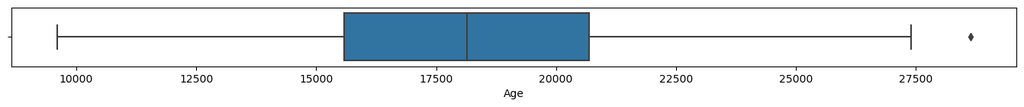

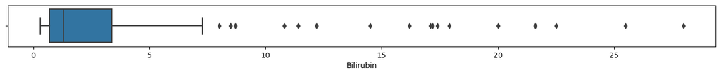

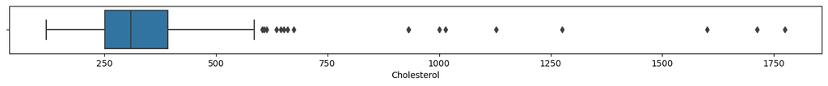

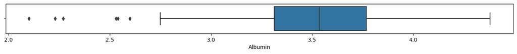

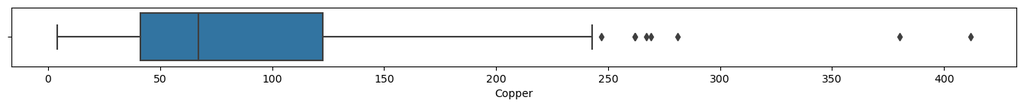

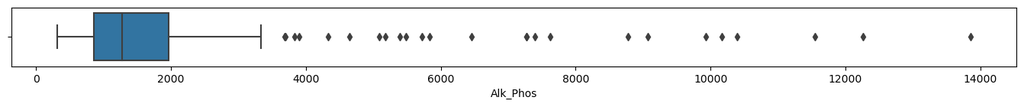

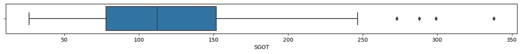

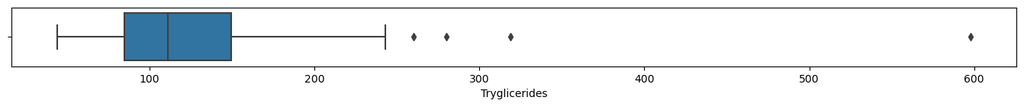

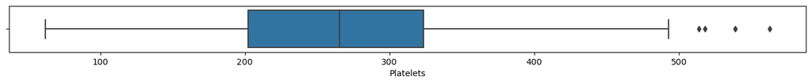

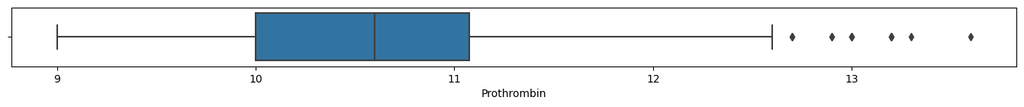

```python
##################################
# Formulating the individual boxplots
# for all numeric columns
##################################
for column in cirrhosis_survival_X_train_imputed_numeric:
        plt.figure(figsize=(17,1))
        sns.boxplot(data=cirrhosis_survival_X_train_imputed_numeric, x=column)
```

### 1.4.4 Collinearity

[Pearson’s Correlation Coefficient](https://royalsocietypublishing.org/doi/10.1098/rsta.1896.0007) is a parametric measure of the linear correlation for a pair of features by calculating the ratio between their covariance and the product of their standard deviations. The presence of high absolute correlation values indicate the univariate association between the numeric predictors and the numeric response.

```python
##################################
# Formulating a function
# to plot the correlation matrix
# for all pairwise combinations
# of numeric columns
##################################
def plot_correlation_matrix(corr, mask=None):
    f, ax = plt.subplots(figsize=(11, 9))
    sns.heatmap(corr,
                ax=ax,
                mask=mask,
                annot=True,
                vmin=-1,
                vmax=1,
                center=0,
                cmap='coolwarm',
                linewidths=1,
                linecolor='gray',
                cbar_kws={'orientation': 'horizontal'})
```

```python
##################################
# Computing the correlation coefficients
# and correlation p-values
# among pairs of numeric columns
##################################
cirrhosis_survival_X_train_imputed_numeric_correlation_pairs = {}
cirrhosis_survival_X_train_imputed_numeric_columns = cirrhosis_survival_X_train_imputed_numeric.columns.tolist()
for numeric_column_a, numeric_column_b in itertools.combinations(cirrhosis_survival_X_train_imputed_numeric_columns, 2):
    cirrhosis_survival_X_train_imputed_numeric_correlation_pairs[numeric_column_a + '_' + numeric_column_b] = stats.pearsonr(
        cirrhosis_survival_X_train_imputed_numeric.loc[:, numeric_column_a],
        cirrhosis_survival_X_train_imputed_numeric.loc[:, numeric_column_b])
```

```python
##################################
# Formulating the pairwise correlation summary
# for all numeric columns
##################################
cirrhosis_survival_X_train_imputed_numeric_summary = cirrhosis_survival_X_train_imputed_numeric.from_dict(cirrhosis_survival_X_train_imputed_numeric_correlation_pairs, orient='index')
cirrhosis_survival_X_train_imputed_numeric_summary.columns = ['Pearson.Correlation.Coefficient', 'Correlation.PValue']
display(cirrhosis_survival_X_train_imputed_numeric_summary.sort_values(by=['Pearson.Correlation.Coefficient'], ascending=False).head(20))
```

|  | Pearson.Correlation.Coefficient | Correlation.PValue |
| --- | --- | --- |
| Bilirubin_SGOT | 0.503007 | 2.210899e-15 |
| Bilirubin_Copper | 0.444366 | 5.768566e-12 |
| Bilirubin_Tryglicerides | 0.389493 | 2.607951e-09 |
| Bilirubin_Cholesterol | 0.348174 | 1.311597e-07 |
| Bilirubin_Prothrombin | 0.344724 | 1.775156e-07 |
| Copper_SGOT | 0.305052 | 4.475849e-06 |
| Cholesterol_SGOT | 0.280530 | 2.635566e-05 |
| Alk_Phos_Tryglicerides | 0.265538 | 7.199789e-05 |
| Cholesterol_Tryglicerides | 0.257973 | 1.169491e-04 |
| Copper_Tryglicerides | 0.256448 | 1.287335e-04 |
| Copper_Prothrombin | 0.232051 | 5.528189e-04 |
| Copper_Alk_Phos | 0.215001 | 1.404964e-03 |
| Alk_Phos_Platelets | 0.182762 | 6.814702e-03 |
| SGOT_Tryglicerides | 0.176605 | 8.972028e-03 |
| SGOT_Prothrombin | 0.170928 | 1.147644e-02 |
| Albumin_Platelets | 0.170836 | 1.152154e-02 |
| Cholesterol_Copper | 0.165834 | 1.422873e-02 |
| Cholesterol_Alk_Phos | 0.165814 | 1.424066e-02 |
| Age_Prothrombin | 0.157493 | 1.999022e-02 |
| Cholesterol_Platelets | 0.152235 | 2.458130e-02 |

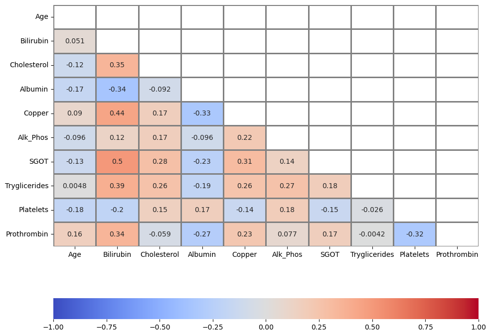

```python
##################################
# Plotting the correlation matrix
# for all pairwise combinations
# of numeric columns
##################################
cirrhosis_survival_X_train_imputed_numeric_correlation = cirrhosis_survival_X_train_imputed_numeric.corr()
mask = np.triu(cirrhosis_survival_X_train_imputed_numeric_correlation)
plot_correlation_matrix(cirrhosis_survival_X_train_imputed_numeric_correlation,mask)
plt.show()
```

```python
##################################
# Formulating a function
# to plot the correlation matrix
# for all pairwise combinations
# of numeric columns
# with significant p-values only
##################################
def correlation_significance(df=None):
    p_matrix = np.zeros(shape=(df.shape[1],df.shape[1]))
    for col in df.columns:
        for col2 in df.drop(col,axis=1).columns:
            _ , p = stats.pearsonr(df[col],df[col2])
            p_matrix[df.columns.to_list().index(col),df.columns.to_list().index(col2)] = p
    return p_matrix
```

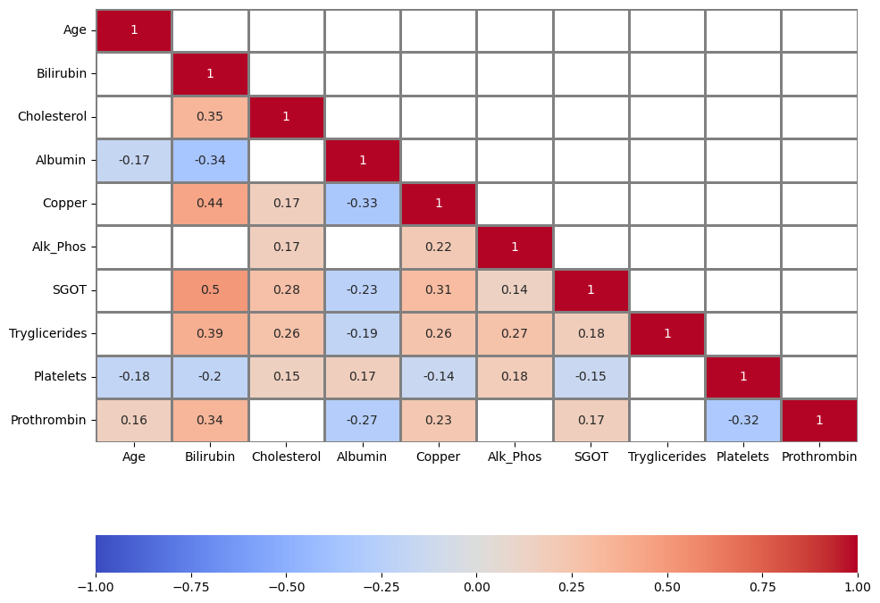

```python
##################################
# Plotting the correlation matrix
# for all pairwise combinations
# of numeric columns
# with significant p-values only
##################################
cirrhosis_survival_X_train_imputed_numeric_correlation_p_values = correlation_significance(cirrhosis_survival_X_train_imputed_numeric)
mask = np.invert(np.tril(cirrhosis_survival_X_train_imputed_numeric_correlation_p_values<0.05))
plot_correlation_matrix(cirrhosis_survival_X_train_imputed_numeric_correlation,mask)
```

### 1.4.5 Shape Transformation

[Yeo-Johnson Transformation](https://academic.oup.com/biomet/article-abstract/87/4/954/232908?redirectedFrom=fulltext&login=false) applies a new family of distributions that can be used without restrictions, extending many of the good properties of the Box-Cox power family. Similar to the Box-Cox transformation, the method also estimates the optimal value of lambda but has the ability to transform both positive and negative values by inflating low variance data and deflating high variance data to create a more uniform data set. While there are no restrictions in terms of the applicable values, the interpretability of the transformed values is more diminished as compared to the other methods.

```python
##################################
# Formulating a data subset containing
# variables with noted outliers
##################################
X_train_predictors_with_outliers = ['Bilirubin','Cholesterol','Albumin','Copper','Alk_Phos','SGOT','Tryglicerides','Platelets','Prothrombin']
cirrhosis_survival_X_train_imputed_numeric_with_outliers = cirrhosis_survival_X_train_imputed_numeric[X_train_predictors_with_outliers]
```

```python
##################################
# Conducting a Yeo-Johnson Transformation
# to address the distributional
# shape of the variables
##################################
yeo_johnson_transformer = PowerTransformer(method='yeo-johnson',
                                          standardize=False)
cirrhosis_survival_X_train_imputed_numeric_with_outliers_array = yeo_johnson_transformer.fit_transform(cirrhosis_survival_X_train_imputed_numeric_with_outliers)
```

```python
##################################
# Formulating a new dataset object
# for the transformed data
##################################
cirrhosis_survival_X_train_transformed_numeric_with_outliers = pd.DataFrame(cirrhosis_survival_X_train_imputed_numeric_with_outliers_array,
                                                                            columns=cirrhosis_survival_X_train_imputed_numeric_with_outliers.columns)
cirrhosis_survival_X_train_transformed_numeric = pd.concat([cirrhosis_survival_X_train_imputed_numeric[['Age']],
                                                            cirrhosis_survival_X_train_transformed_numeric_with_outliers],
                                                           axis=1)
```

```python
cirrhosis_survival_X_train_transformed_numeric.head()
```

|  | Age | Bilirubin | Cholesterol | Albumin | Copper | Alk_Phos | SGOT | Tryglicerides | Platelets | Prothrombin |
| --- | --- | --- | --- | --- | --- | --- | --- | --- | --- | --- |
| 0 | 13329 | 0.830251 | 1.528771 | 25.311621 | 4.367652 | 2.066062 | 7.115310 | 3.357597 | 58.787709 | 0.236575 |
| 1 | 12912 | 0.751147 | 1.535175 | 34.049208 | 6.244827 | 2.047167 | 7.303237 | 3.581345 | 57.931137 | 0.236572 |
| 2 | 17180 | 0.491099 | 1.523097 | 32.812930 | 5.320861 | 2.043970 | 7.278682 | 2.990077 | 61.554228 | 0.236573 |
| 3 | 17884 | 0.760957 | 1.505628 | 30.818146 | 5.264915 | 2.062590 | 7.170942 | 3.288822 | 29.648190 | 0.236575 |
| 4 | 15177 | 0.893603 | 1.519249 | 26.533792 | 6.440904 | 2.109170 | 8.385199 | 3.284118 | 43.198326 | 0.236572 |

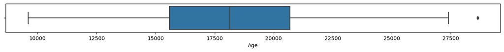

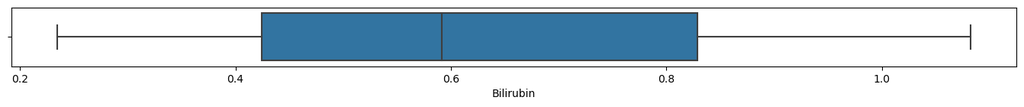

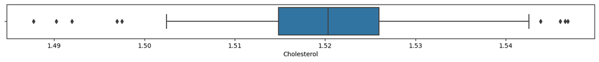

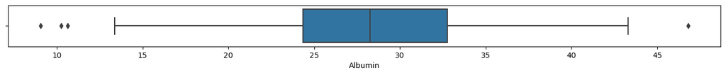

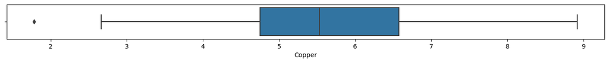

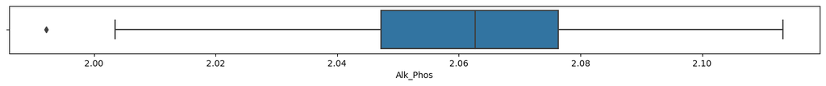

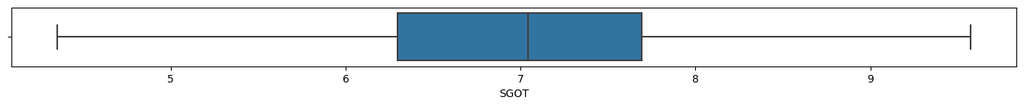

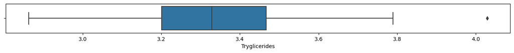

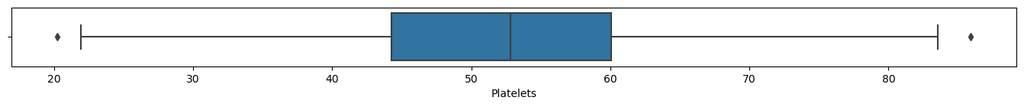

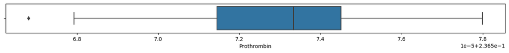

```python
##################################
# Formulating the individual boxplots
# for all transformed numeric columns
##################################
for column in cirrhosis_survival_X_train_transformed_numeric:
        plt.figure(figsize=(17,1))
        sns.boxplot(data=cirrhosis_survival_X_train_transformed_numeric, x=column)
```

```python
##################################
# Formulating the outlier summary
# for all numeric columns
##################################
X_train_numeric_variable_name_list = list(cirrhosis_survival_X_train_transformed_numeric.columns)
X_train_numeric_skewness_list = cirrhosis_survival_X_train_transformed_numeric.skew()
cirrhosis_survival_X_train_transformed_numeric_q1 = cirrhosis_survival_X_train_transformed_numeric.quantile(0.25)
cirrhosis_survival_X_train_transformed_numeric_q3 = cirrhosis_survival_X_train_transformed_numeric.quantile(0.75)
cirrhosis_survival_X_train_transformed_numeric_iqr = cirrhosis_survival_X_train_transformed_numeric_q3 - cirrhosis_survival_X_train_transformed_numeric_q1
X_train_numeric_outlier_count_list = ((cirrhosis_survival_X_train_transformed_numeric < (cirrhosis_survival_X_train_transformed_numeric_q1 - 1.5 * cirrhosis_survival_X_train_transformed_numeric_iqr)) | (cirrhosis_survival_X_train_transformed_numeric > (cirrhosis_survival_X_train_transformed_numeric_q3 + 1.5 * cirrhosis_survival_X_train_transformed_numeric_iqr))).sum()
X_train_numeric_row_count_list = list([len(cirrhosis_survival_X_train_transformed_numeric)] * len(cirrhosis_survival_X_train_transformed_numeric.columns))
X_train_numeric_outlier_ratio_list = map(truediv, X_train_numeric_outlier_count_list, X_train_numeric_row_count_list)

X_train_numeric_column_outlier_summary = pd.DataFrame(zip(X_train_numeric_variable_name_list,
                                                          X_train_numeric_skewness_list,
                                                          X_train_numeric_outlier_count_list,
                                                          X_train_numeric_row_count_list,
                                                          X_train_numeric_outlier_ratio_list),
                                        columns=['Numeric.Column.Name',
                                                 'Skewness',
                                                 'Outlier.Count',
                                                 'Row.Count',
                                                 'Outlier.Ratio'])
display(X_train_numeric_column_outlier_summary.sort_values(by=['Outlier.Count'], ascending=False))
```

|  | Numeric.Column.Name | Skewness | Outlier.Count | Row.Count | Outlier.Ratio |
| --- | --- | --- | --- | --- | --- |
| 2 | Cholesterol | -0.083072 | 9 | 218 | 0.041284 |
| 3 | Albumin | 0.006523 | 4 | 218 | 0.018349 |
| 8 | Platelets | -0.019323 | 2 | 218 | 0.009174 |
| 0 | Age | 0.223080 | 1 | 218 | 0.004587 |
| 4 | Copper | -0.010240 | 1 | 218 | 0.004587 |
| 5 | Alk_Phos | 0.027977 | 1 | 218 | 0.004587 |
| 7 | Tryglicerides | -0.000881 | 1 | 218 | 0.004587 |
| 9 | Prothrombin | 0.000000 | 1 | 218 | 0.004587 |
| 1 | Bilirubin | 0.263101 | 0 | 218 | 0.000000 |
| 6 | SGOT | -0.008416 | 0 | 218 | 0.000000 |